# Chapter 6 Plots

Jim Albert

June 8, 2017

### Ballpark Effects

Load some necessary packages.

```r
library(dplyr)
library(ggplot2)
library(stringr)
library(Lahman)
library(readr)
```

#### The Data

The ESPN home run tracker http://www.hittrackeronline.com/ contains a number of variables for each home run hit during the current season. I collected this data for five baseball seasons (2012 through 2016) and the csv file homeruns.csv contains data on 24,299 home runs hit during these five seasons.

```r
d <- read_csv("https://bayesball.github.io/VB/data/homeruns.csv")
head(d)
```

```
## # A tibble: 6 x 16
##      Date Video  Path          Hitter H_Team            Pitcher P_Team
##     <chr> <chr> <chr>           <chr>  <chr>              <chr>  <chr>
## 1 10/3/12 Video  View  Longoria, Evan     TB      Arrieta, Jake    BAL
## 2 10/3/12 Video  View    Johnson, Dan    CHW        Huff, David    CLE
## 3 10/3/12 Video  View Maybin, Cameron     SD  Kintzler, Brandon    MIL
## 4 10/3/12 Video  View  Cano, Robinson    NYY Mortensen, Clayton    BOS
## 5 10/3/12 Video  View    Moore, Tyler    WSH         Lee, Cliff    PHI
## 6 10/3/12 Video  View  Longoria, Evan     TB     Tillman, Chris    BAL
## # ... with 9 more variables: Inning <int>, Ballpark <chr>,
## #   `Type/Luck` <chr>, True_Dist <int>, Speed_off_Bat <dbl>,
## #   Elevation_Angle <dbl>, Horiz_Angle <dbl>, Apex <int>, N_Parks <int>
```

#### (Figure 6.4) distribution of horizontal angle

In the book, I define the horizontal angle which is 180 - Horiz_Angle where `Horiz_Angle` is the definition of the horizontal angle on the website.

Here is a density plot of the collection of horizontal angles.

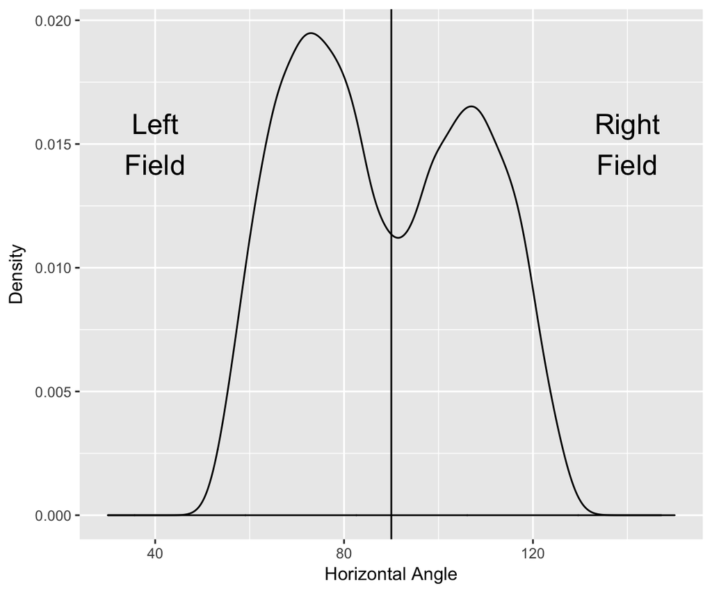

```r
ggplot(d, aes(180 - Horiz_Angle)) +
  geom_density() +
  xlim(30, 180 - 30) +
  xlab("Horizontal Angle") +
  ylab("Density") +
  geom_vline(xintercept=90) +
  annotate("text", x=40, y=0.015,
           label="Left\nField", size=6) +
  annotate("text", x=140, y=0.015,
           label="Right\nField", size=6)
```

#### (Figure 6.5) relationship of distance and horizontal angle

Here I graph the horizontal angle against the home run distance and add a smoothing curve to show the general pattern.

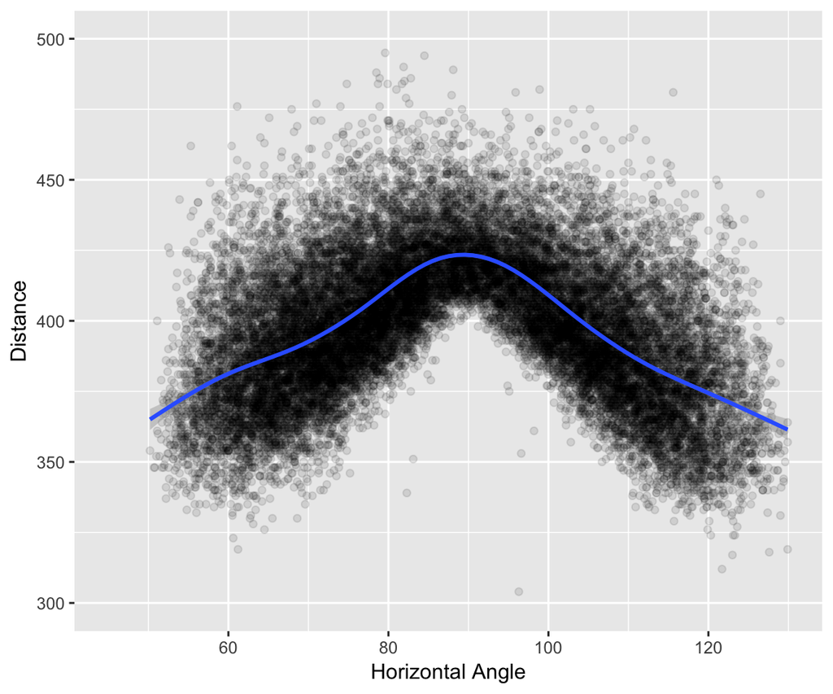

```r
ggplot(d, aes(180 - Horiz_Angle, True_Dist)) +
  geom_point(alpha=0.1) + geom_smooth() +
  ylim(300, 500) + xlim(45, 130) +
  xlab("Horizontal Angle") +
  ylab("Distance")
```

#### Relationship of direction and handedness of batter

Here I get information about the batting side of each hitter and merge this information with the main dataset.

```r
Names <- str_split(d$Hitter, ",")
one_row <- function(j, k)
  str_trim(Names[[j]][k])
d$LastName <- sapply(1:24299, one_row, 1)
d$FirstName <- sapply(1:24299, one_row, 2)
d2 <- inner_join(d,
                 select(Master, nameLast, nameFirst, bats),
                 by=c("LastName"="nameLast",
                      "FirstName"="nameFirst"))
```

```r
d2$Batting <- ifelse(d2$bats=="R",
                     "Right-Handed Hitter",
                     "Left-Handed Hitter")
```

Here I look the right and left batter effects – show how the distribution of the horizontal angle varies among right and left-handed hitters.

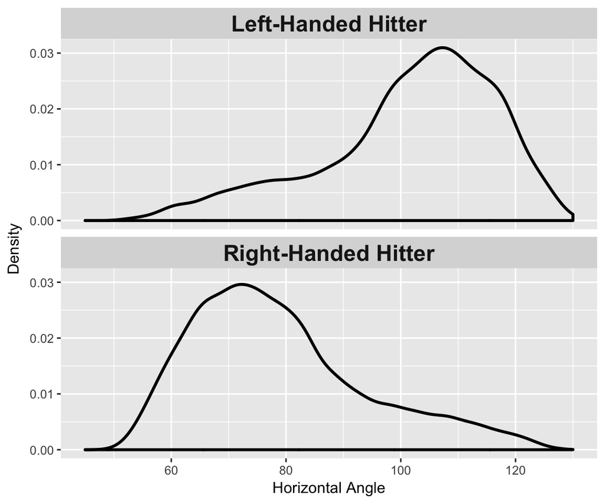

```r
ggplot(filter(d2, bats=="R" | bats=="L"),
       aes(180 - Horiz_Angle)) +
  geom_density(size=1.0)  + xlim(45, 130) +
  xlab("Horizontal Angle") +
  ylab("Density") +
  facet_wrap(~ Batting, ncol=1) +
  theme(strip.text = element_text(face="bold", size=16))
```

#### Ballpark effects

Here I look at the proportion of left-sided hr for all parks (Figure 6.7)

```r
S <- summarise(group_by(d2, Ballpark),
               NL=sum(180 - Horiz_Angle < 90),
               NR=sum(180 - Horiz_Angle > 90),
               PL=NL / (NL + NR))
```

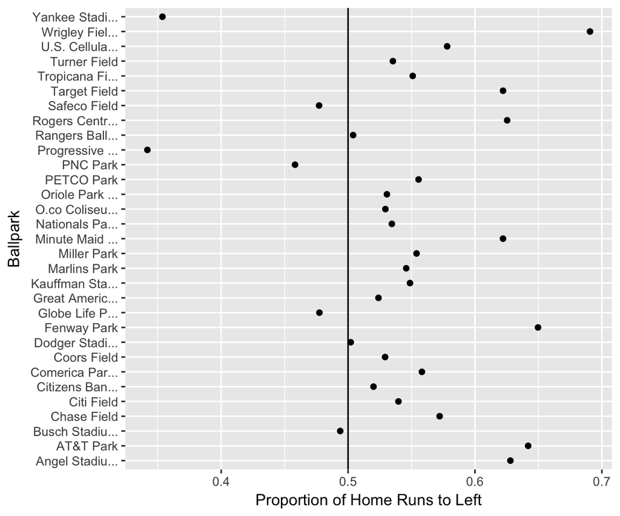

```r
ggplot(filter(S, NL + NR > 200), aes(Ballpark, PL)) +
  geom_point() + coord_flip() +
  ylab("Proportion of Home Runs to Left") +
  geom_hline(yintercept = 0.5)
```

I focus on 12 extreme parks

```r
S200 <- filter(S, NL + NR > 200)
S200 <- arrange(S200, desc(PL))
Sextreme <- rbind(slice(S200, 1:8),
                  slice(S200, 28:31))
ballparks <- as.character(arrange(Sextreme, PL)$Ballpark)
d2$Ballpark <- factor(d2$Ballpark,
                      levels=ballparks)
```

(Figure 6.8) This shows the distribution of the horizontal angle for each of these extreme parks.

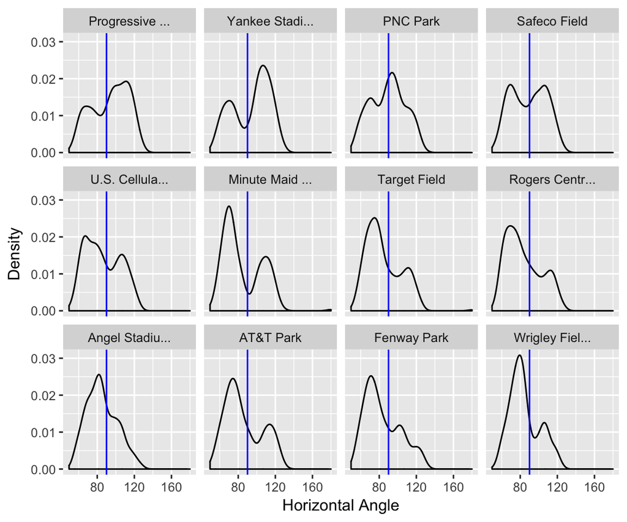

```r
ggplot(filter(d2, bats=="R" | bats=="L",
              Ballpark %in% Sextreme$Ballpark),
       aes(180 - Horiz_Angle)) +
  geom_density() +
  facet_wrap(~ Ballpark, ncol=4) +
  geom_vline(xintercept = 90, color="blue") +
  xlab("Horizontal Angle") + ylab("Density")
```